# 消費者態度の形成メカニズムのモデル化

## (1) 共分散構造分析①

### データ

```r
setwd("D:/R_Appendix")
Dataset <- read.csv("sec7_data.csv")
head(Dataset)
```

|  | PNL | q1 | q2 | q3 | q4 | q5 | q6 | q7 | q8 | q9 | q10 | q11 | q12 | q13 | q14 | q15 | q16 | q17 | q18 | q19 | q20 | q21 | q22 | q23 | q24 | q25 |
| --- | --- | --- | --- | --- | --- | --- | --- | --- | --- | --- | --- | --- | --- | --- | --- | --- | --- | --- | --- | --- | --- | --- | --- | --- | --- | --- |
| 1 | 502 | 4 | 4 | 3 | 2 | 2 | 3 | 2 | 2 | 2 | 2 | 4 | 1 | 5 | 2 | 1 | 4 | 4 | 2 | 2 | 2 | 1 | 1 | 5 | 3 | 4 |
| 2 | 12002 | 3 | 3 | 3 | 3 | 3 | 2 | 3 | 3 | 3 | 3 | 3 | 3 | 3 | 3 | 2 | 3 | 3 | 3 | 3 | 3 | 3 | 3 | 3 | 3 | 3 |
| 3 | 13302 | 3 | 3 | 3 | 3 | 3 | 3 | 3 | 3 | 3 | 3 | 3 | 3 | 3 | 3 | 3 | 3 | 3 | 3 | 3 | 3 | 3 | 3 | 3 | 3 | 3 |
| 4 | 19541 | 3 | 4 | 3 | 2 | 1 | 3 | 2 | 2 | 2 | 3 | 2 | 4 | 3 | 4 | 2 | 3 | 3 | 2 | 3 | 3 | 5 | 4 | 2 | 1 | 3 |
| 5 | 19848 | 3 | 4 | 3 | 1 | 3 | 3 | 3 | 3 | 3 | 3 | 3 | 4 | 4 | 3 | 3 | 3 | 3 | 3 | 3 | 3 | 3 | 3 | 3 | 3 | 3 |
| 6 | 20299 | 3 | 3 | 3 | 3 | 3 | 3 | 3 | 3 | 3 | 3 | 3 | 3 | 3 | 3 | 3 | 3 | 3 | 3 | 3 | 3 | 3 | 3 | 3 | 3 | 3 |

**個人投資家への投資情報源に関する調査データ**（7.2.5節，p.113）

- PNL：回答者ID
- q1～q3：新聞情報 (nwsp)
- q4～q6：雑誌情報 (mgzn)
- q7～q10：専門家情報(expt)
- q11～q15, q23, q25：公的情報(offc)
- q16～q19：Web公的(web1)
- q20～q24：Web私的(web2)

詳細は教科書p.113を参照。

### モデル

省略。教科書p.117を参照。

### 分析①

#### 天井効果（ceiling effect）と床効果（floor effect）

```r
library(psych)  # 事前に psych パッケージのインストールしておくこと
ceiling <- colMeans(Dataset[,-1]) + SD(Dataset[,-1])
floor <- colMeans(Dataset[,-1]) - SD(Dataset[,-1])
effect <- data.frame(ceiling, floor)
print(effect)
```

- `colMeans()`：各列の平均値を計算
- `SD()`：各列の標準偏差を計算
- `Dataset[,-1]`：第1列の回答者IDを除いてデータを指定

```
##      ceiling    floor
## q1  4.101394 2.596582
## q2  4.387360 2.872559
## q3  4.117330 2.697245
## q4  3.521268 1.970230
## q5  3.959319 2.439062
## q6  3.715904 2.327821
## q7  3.618649 2.143294
## q8  3.629122 2.077761
## q9  3.558583 2.124008
## q10 3.718941 2.227618
## q11 4.088481 2.591681
## q12 3.895562 2.368405
## q13 4.190656 2.761570
## q14 3.707589 2.170953
## q15 3.476138 1.958680
## q16 3.701469 2.350353
## q17 3.753116 2.389394
## q18 3.734784 2.388292
## q19 3.790704 2.397150
## q20 3.468993 1.994975
## q21 3.385673 1.794894
## q22 3.595636 2.135538
## q23 3.909755 2.493484
## q24 3.381243 1.890012
## q25 4.331249 2.837982
```

（教科書の表7.2は質問項目の順番に誤り）

#### クロンバックの $\alpha$ 信頼性係数

```r
a1 <- alpha(Dataset[,c("q1", "q2", "q3")])
summary(a1)
# 第2因子以降省略
```

```
##
## Reliability analysis
##  raw_alpha std.alpha G6(smc) average_r S/N    ase mean   sd median_r
##       0.84      0.84    0.79      0.64 5.3 0.0078  3.5 0.65     0.66
```

#### パス係数の推定

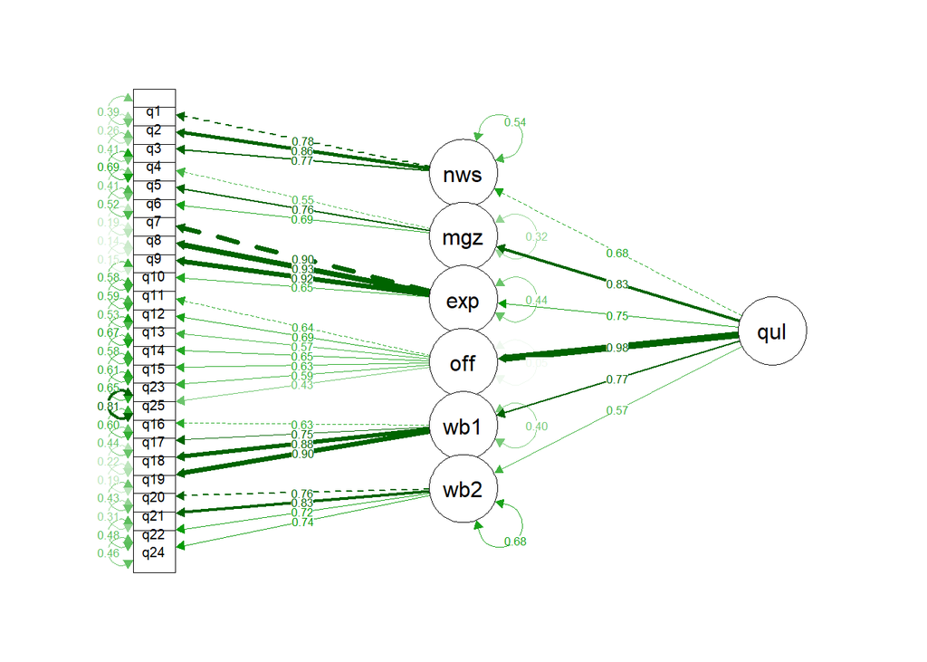

```r
library(lavaan)   # 事前に lavaan パッケージのインストールしておくこと
model <- "
  # 測定方程式
      nwsp =~ q1 + q2 + q3
      mgzn =~ q4 + q5 + q6
      expt =~ q7 + q8 + q9 + q10
      offc =~ q11 + q12 + q13 + q14 + q15 + q23 + q25
      web1 =~ q16 + q17 + q18 + q19
      web2 =~ q20 + q21 + q22 + q24
  # 構造方程式
      qual =~ nwsp + mgzn + expt + offc + web1 + web2
"
fit <- sem(model, data = Dataset)
summary(fit, fit.measures = TRUE, standardized = TRUE)  # パス係数推定値＋モデル比較指標の出力
# fitmeasures(fit)  # その他モデル比較指標の出力

# パス図作成
# library(semPlot)
# semPaths(fit, what = "std", style = "lisrel", rotation = 4, exoVar = FALSE)
```

（推定値の出力省略）

### 分析②（参考）

#### 順序カテゴリカルデータを考慮した分析方法

```r
library(lavaan)
Dataset.c <- Dataset
Dataset.c[,-1] <- lapply(Dataset.c[,-1], ordered)  # データを ordered 型へ変換
ord <- names(Dataset.c)  # ordered 型の列名を抽出（本データでは全列）
model <- "
  # 測定方程式
      nwsp =~ q1 + q2 + q3
      mgzn =~ q4 + q5 + q6
      expt =~ q7 + q8 + q9 + q10
      offc =~ q11 + q12 + q13 + q14 + q15 + q23 + q25
      web1 =~ q16 + q17 + q18 + q19
      web2 =~ q20 + q21 + q22 + q24
  # 構造方程式
      qual =~ nwsp + mgzn + expt + offc + web1 + web2
"
fit <- sem(model, data = Dataset.c, ordered = ord)
summary(fit, fit.measures = TRUE, standardized = TRUE)  # パス係数推定値＋モデル比較指標の出力
# fitmeasures(fit)  # その他モデル比較指標の出力

# パス図作成
# library(semPlot)
# semPaths(fit, what = "std", rotation = 4, style = "lisrel", exoVar = FALSE, intercepts = FALSE)
```

（推定値の出力省略）

[figure not shown]

#### 参考文献

- [The lavaan Project](http://lavaan.ugent.be/index.html)
- [Package ‘lavaan’ - CRAN-R](https://cran.r-project.org/web/packages/lavaan/lavaan.pdf)

## (2) 共分散構造分析②

### データ

```r
setwd("D:/R_Appendix")
Dataset <- read.csv("data_wom.csv")
head(Dataset)
```

|  | id | x1 | x2 | x3 | x4 | x5 | x6 | x7 | x8 | x9 | x10 | x11 | x12 |
| --- | --- | --- | --- | --- | --- | --- | --- | --- | --- | --- | --- | --- | --- |
| 1 | 1 | -1.0801480 | -1.2302912 | -1.5050257 | -0.5458198 | -0.10265119 | -0.5777363 | 0.7362752 | -0.06676086 | -0.3988913 | 0.31057231 | -0.2985108 | -0.08733963 |
| 2 | 2 | 1.7765535 | 1.9608535 | 0.5427575 | 2.8266521 | 0.01184629 | 0.4855598 | -0.1503004 | 0.32457936 | -0.5394977 | 1.13058124 | 0.5764313 | 0.30666210 |
| 3 | 3 | -0.8453421 | 0.4613149 | -2.2101058 | -0.6133485 | -0.82000285 | -1.5321204 | 0.5747578 | 1.94673558 | -0.3329659 | -0.29799534 | -2.5650274 | -2.33130322 |
| 4 | 4 | 1.5609542 | 2.7377580 | 2.0542242 | 1.0246713 | 1.73162640 | 1.2178883 | -0.4641746 | 0.58137138 | 0.6130404 | 0.54875368 | 0.1940160 | -0.14350558 |
| 5 | 5 | 0.9644258 | -0.8542329 | 0.5300646 | 0.9939719 | 1.23794407 | 1.2394316 | -1.1207194 | -1.40770240 | 0.7542113 | -0.03341168 | 0.1198780 | -0.01980437 |
| 6 | 6 | 3.8284121 | 3.0830752 | 2.8301887 | 0.0902647 | 0.78109982 | 1.9878873 | 0.1366761 | 0.21417960 | 0.6179334 | 1.08731298 | 0.3455030 | 0.18845887 |

**クチコミとオピニオン・リーダーに関する調査データ** → [data_wom.csv](https://drive.google.com/file/d/1Sk2Iiqt_BKc9X1gkbpBPTdXwT9mRWJxI/view?usp=sharing)

（里村 (2014)および濱岡・里村 (2009)を元に作成した架空データ）

- id：回答者ID
- オピニオン・リーダー度因子（OPL）の質問項目
  - x1：友人や近所の人と映画についてよく話しをする
  - x2：友人や近所の人に映画の情報を教える方だ
  - x3：友人や近所の人から映画についての情報を求められる方だ
- eオピニオン・リーダー度因子（eOPL）の質問項目
  - x4：インターネット上で映画について投稿したり読んだりする方だ
  - x5：インターネット上で映画の情報を教える方だ
  - x6：インターネット上で人から映画についての情報を求められる方だ
- クチコミ発信因子（WOM）の質問項目
  - x7：満足，面白いと思った映画について友人などに伝える
  - x8：不満，面白くないと思った映画について友人などに伝える
- eクチコミ発信因子（eWOM）の質問項目
  - x9：満足，面白いと思った映画についてインターネットの掲示板などに書き込む
  - x10：不満，面白くないと思った映画についてインターネットの掲示板などに書き込む
- 企業への苦情因子（CLM）の質問項目
  - x11：不満，面白くないと思った映画について映画，配給元に電話する
  - x12：不満，面白くないと思った映画について映画，配給元にメールする

### モデル

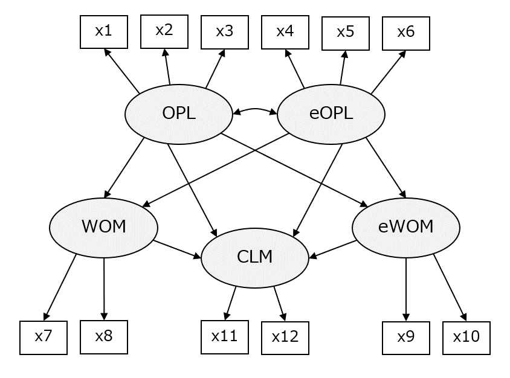

### 分析

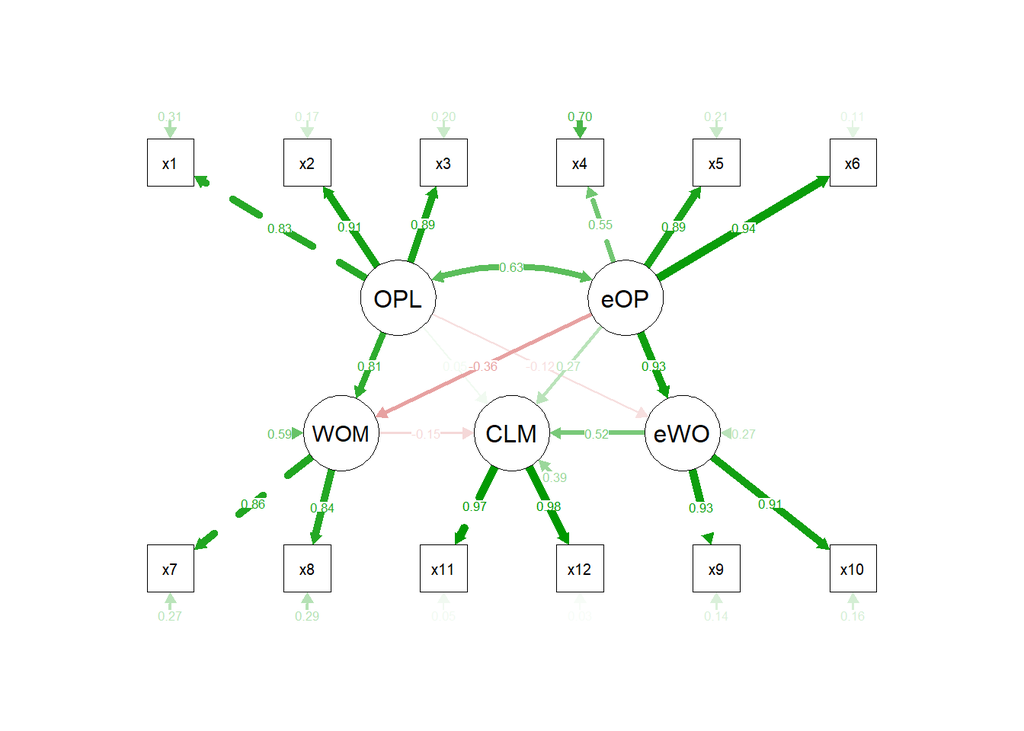

```r
library(lavaan)
model <- "
  # 測定方程式
    OPL =~ x1 + x2 + x3
    eOPL =~ x4 + x5 + x6
    WOM =~ x7 + x8
    eWOM =~ x9 + x10
    CLM =~ x11 + x12
  # 構造方程式
    WOM ~ OPL + eOPL
    eWOM ~ OPL + eOPL
    CLM ~ OPL + eOPL + WOM + eWOM
  # 因子間の相関
    OPL ~~ eOPL
"
fit <- sem(model, data = Dataset)
summary(fit, fit.measures = TRUE, standardized = TRUE)  # パス係数推定値＋モデル比較指標の出力
# fitmeasures(fit)  # その他モデル比較指標の出力

# パス図作成
# library(semPlot)
# semPaths(fit, what = "std", style = "lisrel", reorder = FALSE, optimizeLatRes = TRUE,
#          manifests = c("x1","x2","x3","x4","x5","x6","x7","x8","x11","x12","x9","x10"),
#          latents = c("OPL","eOPL","WOM","CLM","eWOM"))
```

（推定値の出力省略）

#### 参考文献

- [里村卓也 (2014) 『マーケティング・データ分析の基礎』共立出版](http://www.kyoritsu-pub.co.jp/bookdetail/9784320123663)
- [濱岡豊, 里村卓也 (2009) 『消費者間の相互作用についての基礎研究 : クチコミ、eクチコミを中心に』慶應義塾大学出版](http://www.keio-up.co.jp/np/isbn/9784766415971)